# Bayesian SITAR model fit

## Model summary

Summarize the **sitar** model

```
SITAR nonlinear mixed-effects model fit by maximum likelihood
  Call: sitar::sitar(x = age, y = height, id = id, data = data, df = 3)
  Log-likelihood: -1112.306
  Fixed: s1 + s2 + s3 + a + b + c ~ 1
         s1          s2          s3           a           b           c
 12.4379681  28.1344496  31.5941031 133.7696728  -0.9158304   0.5093027

Random effects:
 Formula: list(a ~ 1, b ~ 1, c ~ 1)
 Level: id
 Structure: General positive-definite, Log-Cholesky parametrization
         StdDev    Corr
a        5.8650199 a      b
b        0.8602643  0.150
c        0.1233394  0.341 -0.672
Residual 0.5150428

Number of Observations: 770
Number of Groups: 70
```

Summarize the **bsitar** model

[output not shown]

The figure below shows growth curves adjusted via the random effects. As described earlier (see Introduction), the random effects align individual-specific growth trajectories toward a common population average (mean) trajectory. The three growth patterns that SITAR adjusts via random effects are size, timing, and intensity:

* Size is an individual’s mean height compared to the average (measured in cm). * Timing is the individual’s age at peak height velocity (i.e., the age when they are growing fastest) compared to the average (measured in years). * Intensity is their growth rate compared to the average (measured as a fraction, or percentage divided by 100).

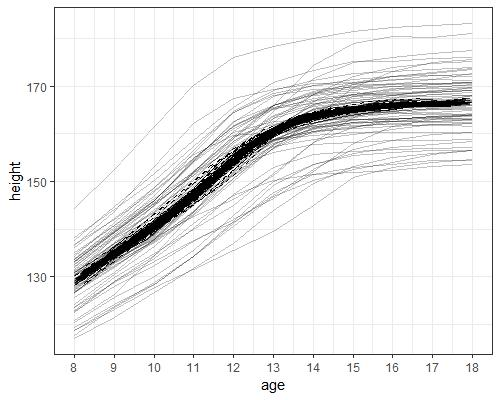

Observed curves along with the superimposed adjusted curves (via random effects) for the **sitar** and **bsitar** models. The observed curves are shown as solid light grey lines whereas the adjusted curves for the **sitar** model are displayed as solid black lines. The adjusted curves for the **bsitar** model are shown as dotted black lines.

## Random effects (size, timing and intensity)

The effect of SITAR adjustment in individual curves via random effects is shown more clearly in the figure below, which displays observed and adjusted curves for the tallest and shortest individuals along with the population average (mean) curve. The corresponding estimates of random effects (size, timing, and intensity) are provided in the tables below. Note that intensity c, multiplied by 100, is a percentage. Results for both models are very similar to each other. Results for the *sitar* model are presented below.

For a broader comparison between *sitar* and *bsitar* models, random effects for the first ten individuals estimated are shown below (see Tables). The association (correlation) between random effects (across all individuals) is shown as a scatterplot in the figures, and corresponding estimates are provided in the tables. Results show that timing is negatively correlated with intensity, indicating that early puberty is associated with faster growth.

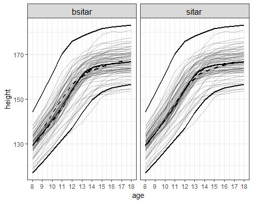

Observed and adjusted curve (via random effects) curves along with the population averag curves for **sitar** and **bsitar** models. The observed curves for all individuals are shown as solid light grey lines whereas curves for the tallest and shortest individuals are displayed using the solid black lines. The adjusted curves for the tallest and shortest individuals are shown as dotted black lines, and the population average curve is shown as solid black line.

Random effects for the tallest and shortest individual - **sitar** model

| id | a | b | c |
| --- | --- | --- | --- |
| 310 | 14.6 | -1.1 | 0.3 |
| 355 | -9.4 | 1.2 | -0.1 |

a: Size (height); b: Timing (age at peak growth velocity, APGV); c: Intensity (peak growth velocity, AGV)

Random effects for the tallest and shortest individual - **bsitar** model

| id | a | b | c |
| --- | --- | --- | --- |
| 310 | 14.5 | -1.1 | 0.3 |
| 355 | -9.4 | 1.2 | -0.2 |

a: Size (height); b: Timing (age at peak growth velocity, APGV); c: Intensity (peak growth velocity, AGV)

Random effects estimates for the first ten individuals - **sitar** model

| id | a | b | c |
| --- | --- | --- | --- |
| 301 | -7.6 | -1.0 | 0.0 |
| 302 | -0.2 | 0.2 | 0.0 |
| 303 | -4.9 | -1.9 | 0.1 |
| 304 | 1.5 | 0.1 | -0.1 |
| 305 | 4.4 | 0.7 | -0.1 |
| 306 | -1.8 | 0.1 | 0.1 |
| 307 | 0.9 | 0.0 | 0.0 |
| 308 | -1.3 | 2.1 | -0.2 |
| 309 | -2.7 | 0.2 | -0.1 |
| 310 | 14.6 | -1.1 | 0.3 |

a: Size (height); b: Timing (age at peak growth velocity, APGV); c: Intensity (peak growth velocity, AGV)

Random effects estimates for the first ten individuals - **bsitar** model

| id | a | b | c |
| --- | --- | --- | --- |
| 301 | -7.6 | -1.0 | 0.0 |
| 302 | -0.2 | 0.2 | 0.0 |
| 303 | -4.9 | -1.9 | 0.1 |
| 304 | 1.5 | 0.1 | -0.1 |
| 305 | 4.3 | 0.7 | -0.1 |
| 306 | -1.8 | 0.1 | 0.1 |
| 307 | 0.9 | 0.0 | 0.0 |
| 308 | -1.3 | 2.1 | -0.2 |
| 309 | -2.7 | 0.2 | -0.1 |
| 310 | 14.5 | -1.1 | 0.3 |

a: Size (height); b: Timing (age at peak growth velocity, APGV); c: Intensity (peak growth velocity, AGV)

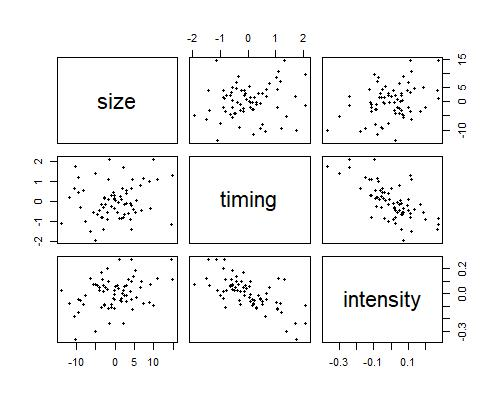

Correlation scatterplot of random effects for the **sitar** model

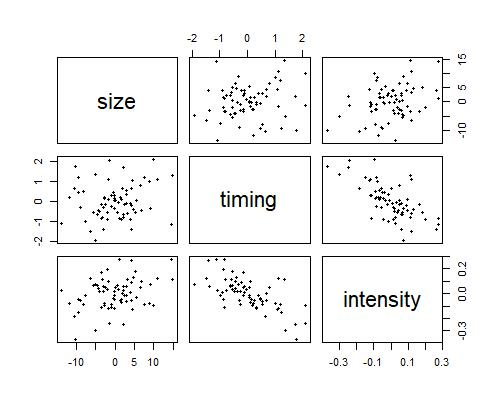

Correlation scatterplot of random effects for the **bsitar** model

Correlation estimates for the random effects - **sitar** model

| a | b | c |
| --- | --- | --- |
| 1.0 | 0.1 | 0.3 |
| 0.1 | 1.0 | -0.7 |
| 0.3 | -0.7 | 1.0 |

a: Size (height); b: Timing (age at peak growth velocity, APGV); c: Intensity (peak growth velocity, AGV)

Correlation estimates for the random effects - **bsitar** model

| a | b | c |
| --- | --- | --- |
| 1.0 | 0.2 | 0.3 |
| 0.2 | 1.0 | -0.7 |
| 0.3 | -0.7 | 1.0 |

a: Size (height); b: Timing (age at peak growth velocity, APGV); c: Intensity (peak growth velocity, AGV)

## Growth curves (distance and velocity)

### Population average (mean) distance and velocity curves

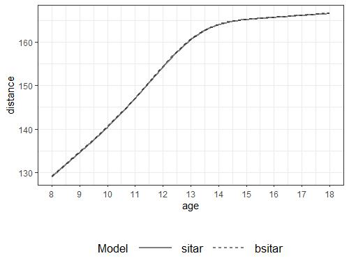

Population average distance curves for the **sitar** and **bsitar** models

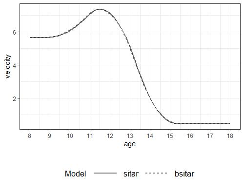

Population average velocity curves for the **sitar** and **bsitar** models

### Individual specific distance and velocity curves

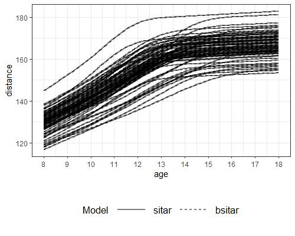

Individual specific distance curves for the **sitar** and **bsitar** models

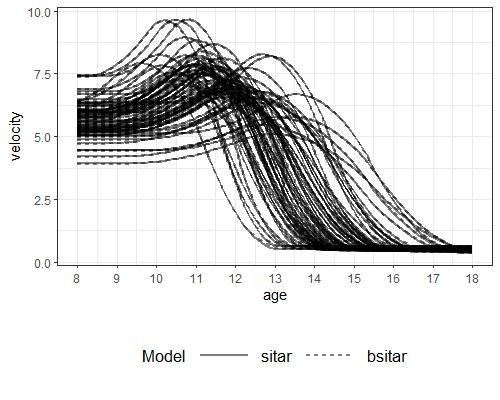

Individual specific velocity curves for the **sitar** and **bsitar** models

## Growth parameters (timing and intensity)

### Population average (mean) estimates

As velocity curves estimated by the *sitar* and *bsitar* models are very similar to each other (see below), it is not surprising that both models provide almost identical estimates for the timing (i.e., age at peak growth velocity, APGV) and the intensity (i.e., peak growth velocity, PGV) of the growth spurt (see table below).

Population average timing and intensity estimates - **sitar** and **bsitar** models

| Parameter | sitar | bsitar |
| --- | --- | --- |
| APGV | 11.5 | 11.5 |
| PGV | 7.4 | 7.3 |

APGV: age at peak growth velocity; PGV: peak growth velocity

### Individual specific estimates

Like the population average estimates, both *sitar* and *bsitar* models provide very similar estimates for the timing (APGV) and the intensity (PGV) of the growth spurt (see tables below).

Individual specific timing and intensity estimates for the first ten individuals - **sitar** model

| id | APGV | PGV |
| --- | --- | --- |
| 301 | 10.5 | 7.2 |
| 302 | 11.6 | 7.0 |
| 303 | 9.6 | 7.9 |
| 304 | 11.6 | 6.9 |
| 305 | 12.1 | 7.0 |
| 306 | 11.6 | 8.1 |
| 307 | 11.5 | 7.6 |
| 308 | 13.4 | 5.8 |
| 309 | 11.7 | 6.8 |
| 310 | 10.5 | 9.7 |

APGV: age at peak growth velocity; PGV: peak growth velocity

Individual specific timing and intensity estimates for the first ten individuals - **bsitar** model

| id | APGV | PGV |
| --- | --- | --- |
| 301 | 10.5 | 7.2 |
| 302 | 11.6 | 7.0 |
| 303 | 9.6 | 7.9 |
| 304 | 11.6 | 6.9 |
| 305 | 12.1 | 7.0 |
| 306 | 11.7 | 8.1 |
| 307 | 11.5 | 7.6 |
| 308 | 13.4 | 5.8 |
| 309 | 11.7 | 6.8 |
| 310 | 10.5 | 9.7 |

APGV: age at peak growth velocity; PGV: peak growth velocity

## References

Cole, T. (2022). *Sitar: Super imposition by translation and rotation growth curve analysis*. https://CRAN.R-project.org/package=sitar

Cole, T. J., Donaldson, M. D. C., & Ben-Shlomo, Y. (2010). SITAR—a useful instrument for growth curve analysis. *International Journal of Epidemiology*, *39*(6), 1558–1566. https://doi.org/10.1093/ije/dyq115

Sandhu, S. (2023). *Bsitar: Bayesian super imposition by translation and rotation growth curve analysis*. https://CRAN.R-project.org/package=bsitar